# Capstone Project

Ji-Eun Park

5/17/2018

## **1.Introduction**

In this project, we have used explored clustering methods for single-cell RNA sequencing data by using the R package *Splatter*. Using *Splatter* with existing single-cell RNA count datasets, we simulated numbers of datasets to see which clustering method is better in clustering single-cell RNA sequencing data. The aim of this project is to determine the optimal clustering method and a set of parameters which most accurately clusters the single-cell RNA data.

## **2. Methods** (need elaboration. not completed)

### 3) Clustering methods

From the simulated datasets, we performed the principal components analysis (PCA) and used the result on k-means algorithm and Partitioning Around Medoids(PAM). For each dataset, first, we observed the adjusted Rand Index for a sequence of practical components for both clustering methods, and second, chose the best princpal component and observed the adjusted Rand Index for a sequence of number of centers.

## **3. Results**

### 1. p63-HBC-diff dataset

```r
# Use p63-HBC-diff data to simulate parameters
# https://github.com/rufletch/p63-HBC-diff
dat1 <- read.table('/Users/jieun/Desktop/CapstoneProject/datasets/counts_table.txt',header=TRUE)
dat1 <- as.matrix(dat1)
dat1 <- na.omit(dat1)
dat1 <- dat1[rowSums(dat1)>0,]
```

## Parameter Estimate

```r
params <- splatEstimate(dat1) # use the data to generate parameters
```

```
## NOTE: Library sizes have been found to be normally distributed instead of log-normal. You may want to check this is correct.
```

```r
pc <- c(2,5,10,20,50) # Try various numbers for PC = (2,5,10,20,50)
simnum <- 3 # number of simulations
ks <- 2:20
```

## Simulation

```r
sim_groups <- lapply(1:simnum, function(i) splatSimulate(params,group.prob = c(0.3,0.3,0.4), method = "groups",verbose = FALSE,de.facLoc=.25, de.facScale=1,seed=i)) #3 simulated data

sim_norm <- lapply(sim_groups,normalise) #normalise simulated data
filtered_counts <- lapply(sim_norm, function(sim) sim[rowSums(logcounts(sim))>0,]) #sort out rows that are not all 0 logcounts

sim_SCE <- lapply(filtered_counts, function(sim) runPCA(sim, ncomponents = 50, method = "irlba", ntop = 1000)) # compute PCA

# (Non-sequential) clustering with kmeans and PAM with k from 2 to 20.
# Take only number of components of interest (2,5,10,20,50)
clust_res <- lapply(sim_SCE, function(sim) clusterMany(sim,ks=2:20,alphas=0.1,betas=0.8,minSizes=1,
            clusterFunction=c("kmeans","pam"), sequential=FALSE,subsample=FALSE,
                  reduceMethod="PCA",nReducedDims=c(2,5,10,20,50),verbose=TRUE))
```

```
## 190 parameter combinations, 0 use sequential method, 0 use subsampling method
## Running Clustering on Parameter Combinations...
```

```
## done.
## 190 parameter combinations, 0 use sequential method, 0 use subsampling method
## Running Clustering on Parameter Combinations...
```

```
## done.
## 190 parameter combinations, 0 use sequential method, 0 use subsampling method
## Running Clustering on Parameter Combinations...
```

```
## done.
```

```r
# (Sequential) clustering with kmeans and PAM with k from 2 to 20.
# Take only number of components of interest (2,5,10,20,50)
clust_res_seq <- lapply(sim_SCE, function(sim) clusterMany(sim,ks=2:20,alphas=0.1,betas=0.8,minSizes=1,
            clusterFunction=c("kmeans","pam"), sequential=TRUE,subsample=FALSE,
                  reduceMethod="PCA",nReducedDims=c(2,5,10,20,50),verbose=TRUE))
```

```
## 190 parameter combinations, 190 use sequential method, 0 use subsampling method
## Running Clustering on Parameter Combinations...
```

[output not shown]

[output cut: 46 more lines]

[output not shown]

```
## done.
## 190 parameter combinations, 190 use sequential method, 0 use subsampling method
## Running Clustering on Parameter Combinations...
```

[output not shown]

[output cut: 8 more lines]

[output not shown]

```
## done.
## 190 parameter combinations, 190 use sequential method, 0 use subsampling method
## Running Clustering on Parameter Combinations...
```

[output not shown]

[output cut: 34 more lines]

[output not shown]

```
## done.
```

```r
# With ClusterExperiment object generate cluster matrix showing the clustered group names of each cell(row)
clust_res_mat <- lapply(clust_res,function(sim) clusterMatrix(sim))
clust_res_seq_mat <- lapply(clust_res_seq,function(sim) clusterMatrix(sim))

# For sequential clustering methods, generate an list of empty matrices
clust_res_mat_seq_NA <- list("1"=matrix(nrow=nrow(clust_res_seq_mat[[1]]),ncol=ncol(clust_res_seq_mat[[1]])),"2"=matrix(nrow=nrow(clust_res_seq_mat[[2]]),ncol=ncol(clust_res_seq_mat[[2]])),"3"=matrix(nrow=nrow(clust_res_seq_mat[[3]]),ncol=ncol(clust_res_seq_mat[[3]])))

# Change group -1 to NA
for (a in 1:simnum) {
  for (b in 1:nrow(clust_res_seq_mat[[1]])) {
    for (c in 1:ncol(clust_res_seq_mat[[1]])) {
      clust_res_mat_seq_NA[[a]][b,c] <- ifelse(clust_res_seq_mat[[a]][b,c]=="-1",NA,clust_res_seq_mat[[a]][b,c])
    }
  }
}

# assign colnames to new list of matrices
for (i in 1:simnum) {
  colnames(clust_res_mat_seq_NA[[i]]) <- colnames(clust_res_seq_mat[[i]])
}

# if a column is all NA change everything is Group1
clust_res_mat_NA_fixed <- lapply(clust_res_mat_seq_NA, function(x) {
  idx <- which(colSums(is.na(x)) == NROW(x))
  x[,idx] <- 1
  return(x)
})

# divide the matrices in list to kmeans matrices and pam matrices
kmenasMat <- lapply(clust_res_mat, function(sim) sim[,1:95])
pamMat <- lapply(clust_res_mat, function(sim) sim[,96:190])

kmeansMat2 <- lapply(clust_res_mat_NA_fixed, function(sim) sim[,1:95])
pamMat2 <- lapply(clust_res_mat_NA_fixed, function(sim) sim[,96:190])

ks=2:20
```

## Clustering

### Non-sequential Kmeans

```r
# kmeans for each pc regardless of k
kmeans_by_pc <- lapply(1:length(pc), function (i) {
  lapply(1:simnum,function (j) {
    lapply(1:length(ks), function (s) {
      col_num <- 5*(s-1)+i
      comparing.Partitions(kmenasMat[[j]][,col_num],sim_norm[[j]]$Group)
    })
  })
})

avg_kmean_by_pc <- lapply(1:length(pc), function(i) {
    lapply(1:simnum,function (j) {
      mean(unlist(kmeans_by_pc[[i]][[j]]))
    })
})

avg_kmean_by_pc <- lapply(1:length(pc), function(i){
  mean(unlist(avg_kmean_by_pc[[i]]))
})

avg_kmean_by_pc <- unlist(avg_kmean_by_pc)
```

### Non-sequential PAM

```r
# pam for each pc regardless of k
pam_by_pc <- lapply(1:length(pc), function (i) {
  lapply(1:simnum,function (j) {
    lapply(1:length(ks), function (s) {
      col_num <- 5*(s-1)+i
      comparing.Partitions(pamMat[[j]][,col_num],sim_norm[[j]]$Group)
    })
  })
})

avg_pam_by_pc <- lapply(1:length(pc), function(i) {
    lapply(1:simnum,function (j) {
      mean(unlist(pam_by_pc[[i]][[j]]))
    })
})

avg_pam_by_pc <- lapply(1:length(pc), function(i){
  mean(unlist(avg_pam_by_pc[[i]]))
})

# Unlist for plotting
avg_pam_by_pc <- unlist(avg_pam_by_pc)
```

### Sequantial Kmeans

```r
# kmeans for each pc regardless of k
kmeans_by_pc2 <- lapply(1:length(pc), function (i) {
  lapply(1:simnum,function (j) {
    lapply(1:length(ks), function (s) {
      col_num <- 5*(s-1)+i
      comparing.Partitions(kmeansMat2[[j]][,col_num],sim_norm[[j]]$Group)
    })
  })
})

avg_kmean_by_pc2 <- lapply(1:length(pc), function(i) {
    lapply(1:simnum,function (j) {
      mean(unlist(kmeans_by_pc2[[i]][[j]]))
    })
})

avg_kmean_by_pc2 <- lapply(1:length(pc), function(i){
  mean(unlist(avg_kmean_by_pc2[[i]]))
})

avg_kmean_by_pc2 <- unlist(avg_kmean_by_pc2)
```

### Sequential PAM

```r
pam_by_pc2 <- lapply(1:length(pc), function (i) {
  lapply(1:simnum,function (j) {
    lapply(1:length(ks), function (s) {
      col_num <- 5*(s-1)+i
      comparing.Partitions(pamMat2[[j]][,col_num],sim_norm[[j]]$Group)
    })
  })
})

avg_pam_by_pc2 <- lapply(1:length(pc), function(i) {
    lapply(1:simnum,function (j) {
      mean(unlist(pam_by_pc2[[i]][[j]]))
    })
})

avg_pam_by_pc2 <- lapply(1:length(pc), function(i){
  mean(unlist(avg_pam_by_pc2[[i]]))
})

# Unlist for plotting
avg_pam_by_pc2 <- unlist(avg_pam_by_pc2)
```

## Plots for Average Rand Index(Y) for each number of Component(X)

### Non-Sequential

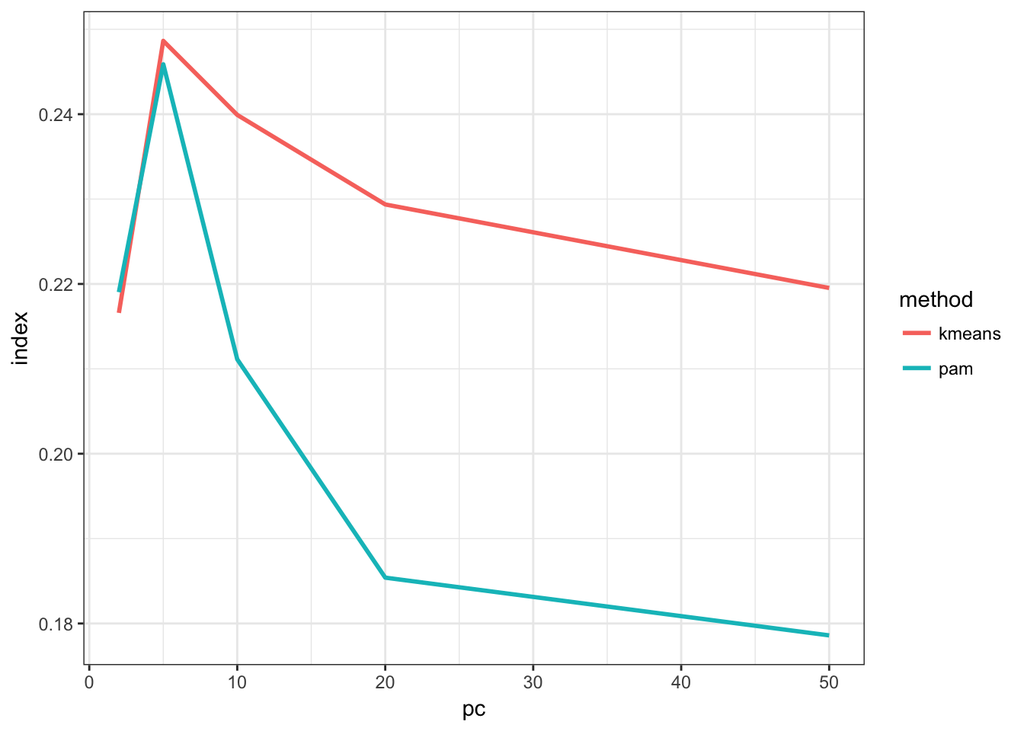

```r
# Make a dataframe including all Indexes
avg_ari <- data.frame(c(rep("kmeans",length(pc)),rep("pam",length(pc))),rep(pc,2),c(avg_kmean_by_pc,avg_pam_by_pc))

colnames(avg_ari) <- c("method","pc","index")

# Plot for AARI
ggplot(avg_ari,aes(x=pc,y=index,group=method,col=method)) +
  geom_smooth(stat = "identity", position = "identity") +
  theme_bw()
```